# Static Report for Mobile Phone Survey Data

Martin Ng

24-10-2024

# Calculations

### Q1: Respondent Variables

In percentage terms, how were the survey’s respondents divided into categories for the following variables?

#### Age Group

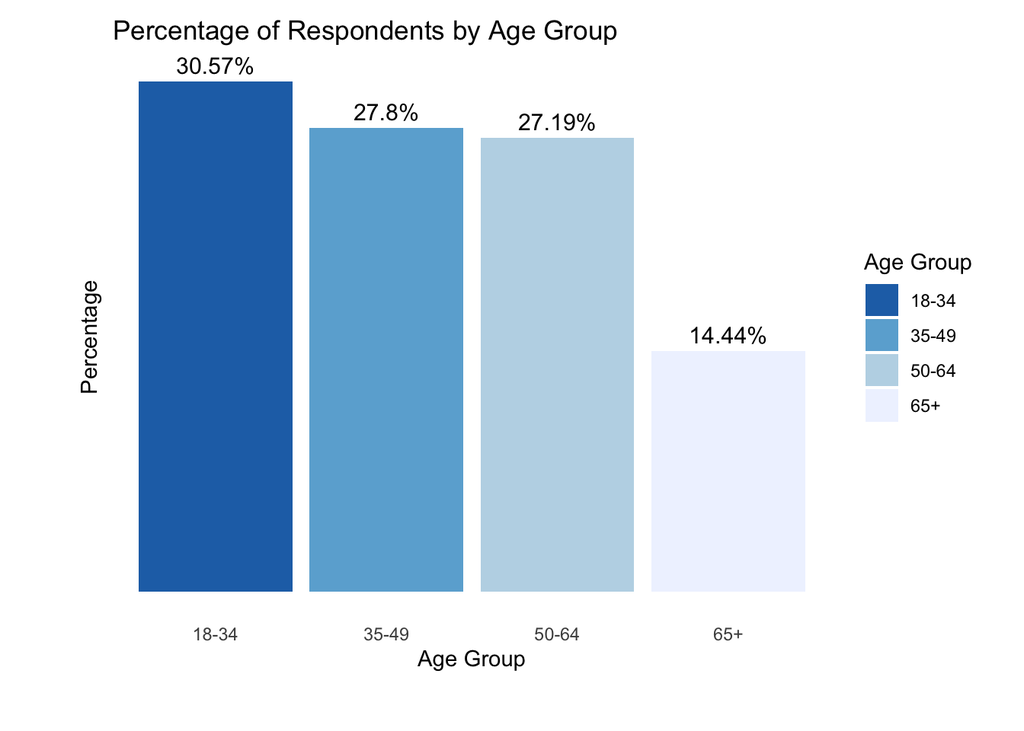

#### Gender

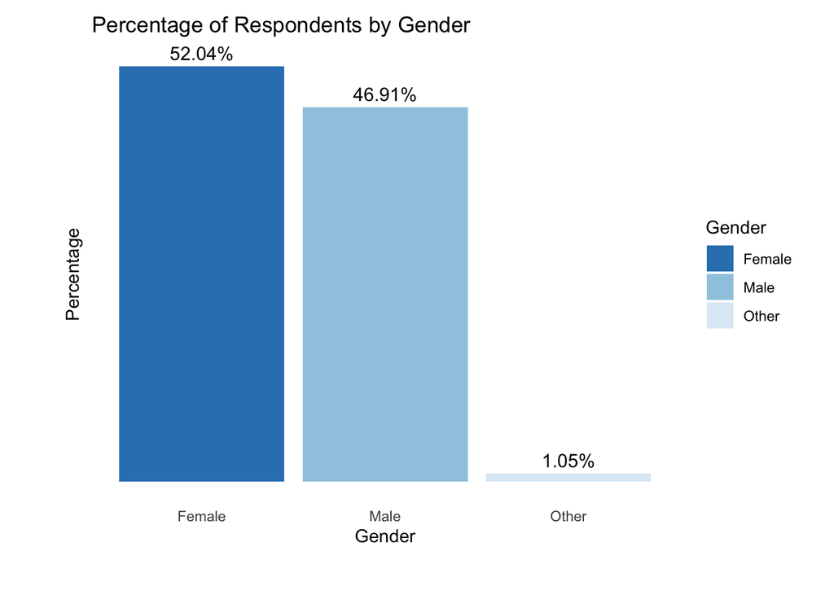

#### Income Group

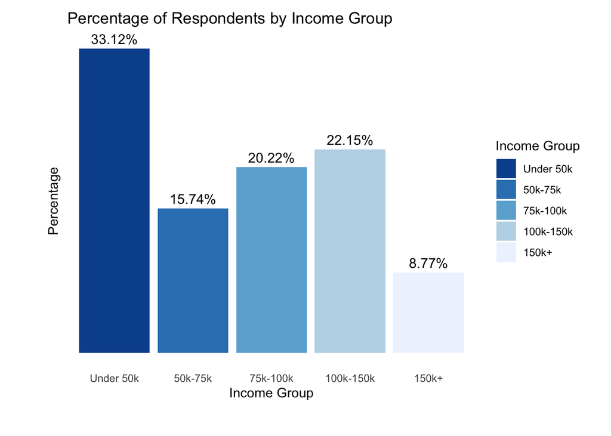

#### Region

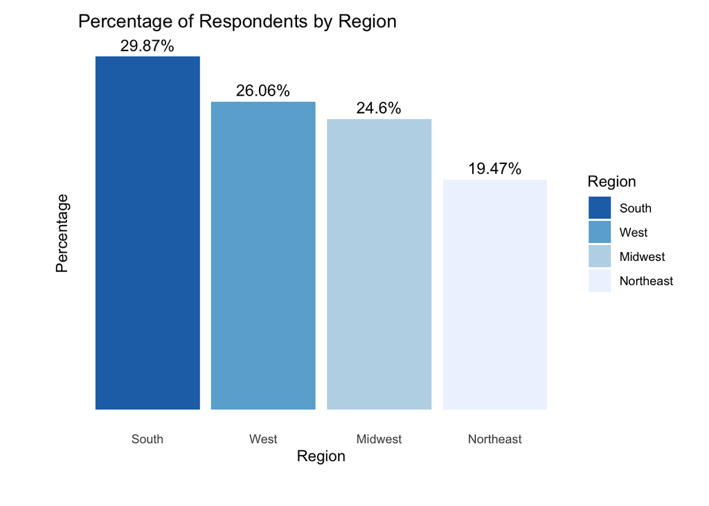

#### Persona

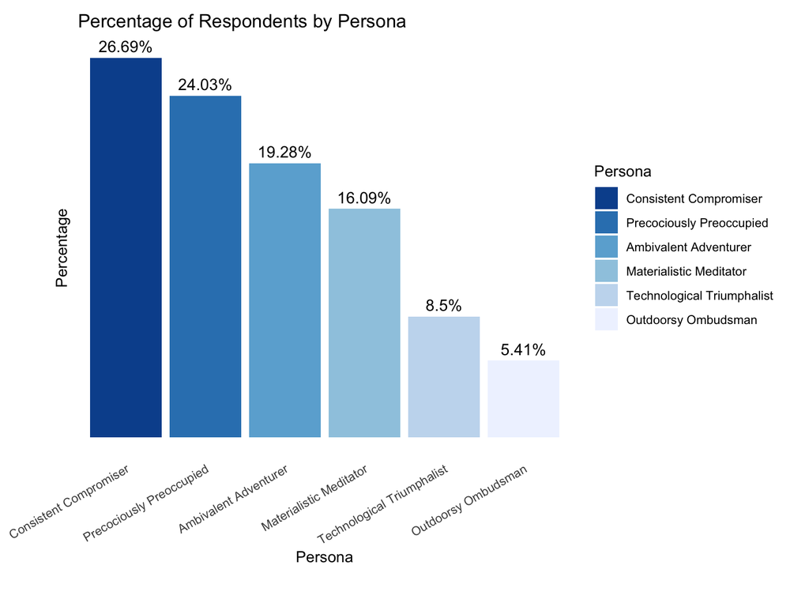

### Q2: Segmented Outcomes

#### Part A

What are the **top 5 products** by **Awareness rates** in the **Northeast**?

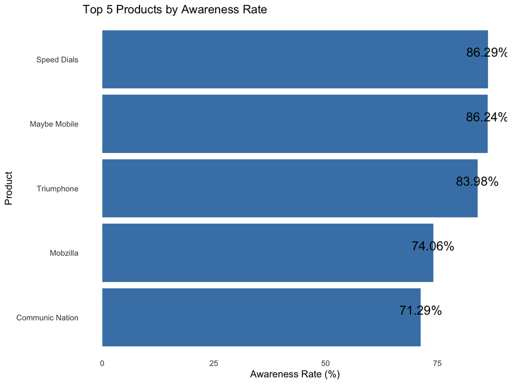

#### Part B

What are the **top 5 products** by **advocacy rates** among **female** respondents who earn **at least $100,000**?

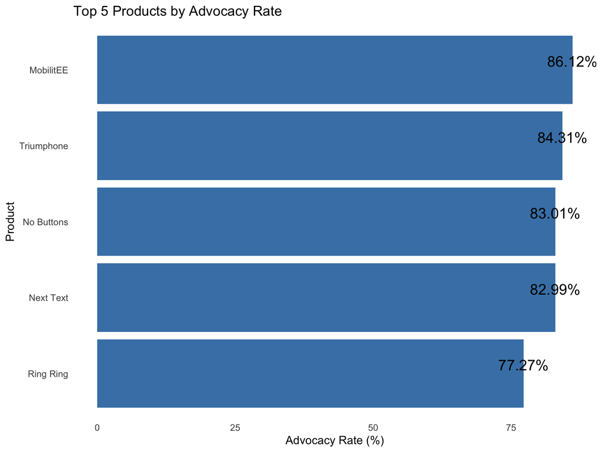

### Q3: Overall Brand Perceptions

What are the **top 5 brands** by the **overall average perception**?

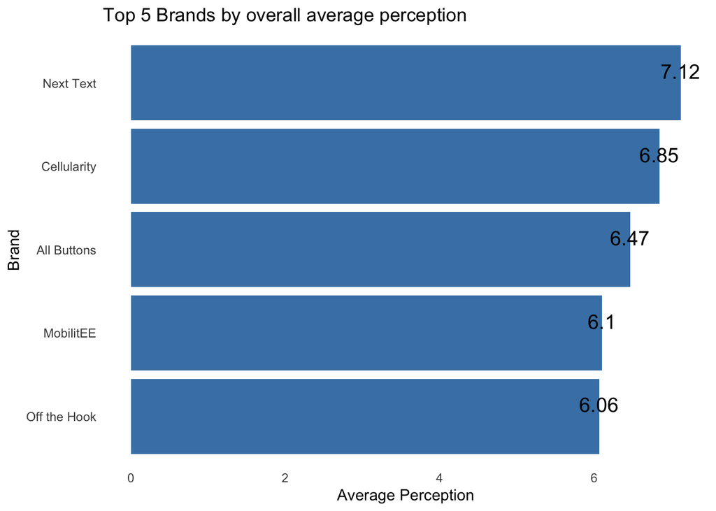

### Q4: Gaps in Outcomes

#### Part A

Which 5 products have the **largest gap** between the **rate of consumption** and the **rate of awareness**?

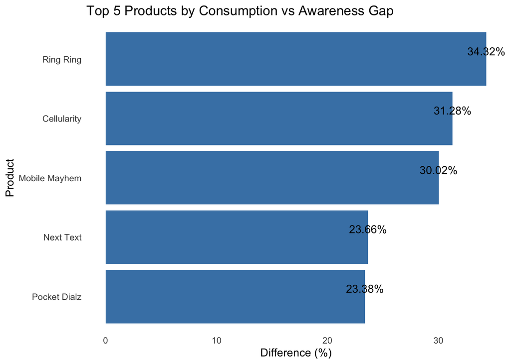

#### Part B

Which 5 products have the **largest gap** between the **rate of awareness** and the **average satisfaction**?

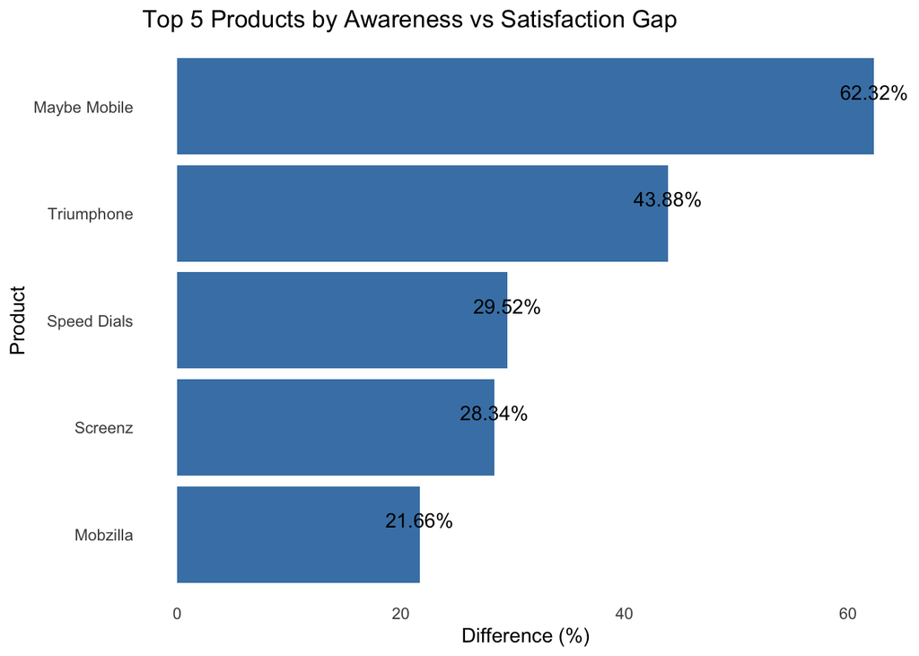

### Q5: Aggregated Engagement

#### Part A

How much impact does respondent’s **overall trends in awareness** have for that person’s **awareness with Buzzdial phones**?

| Variable | Odds.Ratio | OR.Lower.95 | OR.Upper.95 | Pr(>\|z\|) |
| --- | --- | --- | --- | --- |
| aggregated_awareness | 0.452 | 0.298 | 0.684 | 0 |
| Age_Group35-49 | 0.81 | 0.724 | 0.906 | 0 |
| Age_Group50-64 | 0.491 | 0.435 | 0.554 | 0 |
| Age_Group65+ | 0.459 | 0.394 | 0.534 | 0 |
| GenderMale | 0.776 | 0.708 | 0.85 | 0 |
| RegionNortheast | 1.353 | 1.177 | 1.555 | 0 |
| RegionWest | 2.115 | 1.863 | 2.401 | 0 |
| (Intercept) | 0.649 | 0.486 | 0.867 | 0.003 |
| PersonaTechnological Triumphalist | 0.838 | 0.691 | 1.017 | 0.073 |
| Income_Group150k+ | 1.155 | 0.976 | 1.368 | 0.094 |

[output cut: 9 more lines]

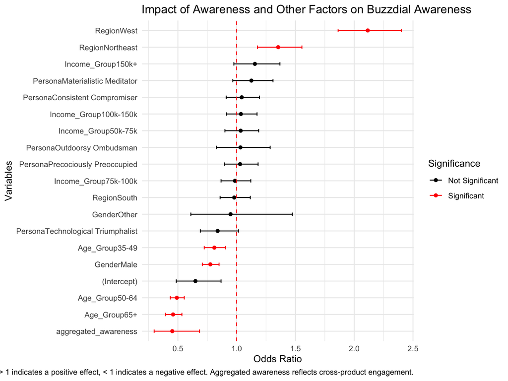

**Results**:

Aggregated awareness has a **Significant** negative impact on awareness of Buzzdial phones. The odds ratio of **0.452** means respondents with higher aggregated awareness of other products are less likely to be aware of Buzzdial phones.

**Interpretation**:

Higher awareness of other brands or products crowds out the likelihood of awareness of Buzzdial phones. Buzzdial faces more difficulty gaining brand awareness among individuals who are already highly familiar with competing products in the same market. This suggests that Buzzdial may need to target audiences with lower existing awareness of competitors or increase its marketing efforts to stand out in a crowded market.

Other variables:

- **Age and gender** are significant factors, with younger individuals and women being more likely to be aware of Buzzdial phones.
- **Region** has a very strong effect, especially in the West and Northeast, indicating possible regional marketing success or regional product appeal.

#### Part B

How much impact does respondent’s **overall trends in satisfaction** have for that person’s **satisfaction with Buzzdial phones**?

| Variable | Coefficient | Pr(>\|z\|) |
| --- | --- | --- |
| (Intercept) | 0.324 | 0 |
| PersonaConsistent Compromiser | 0.146 | 0 |
| PersonaMaterialistic Meditator | 0.124 | 0.002 |
| Age_Group65+ | -0.097 | 0.003 |
| Age_Group35-49 | -0.049 | 0.037 |
| Income_Group100k-150k | -0.055 | 0.042 |
| PersonaTechnological Triumphalist | 0.104 | 0.045 |
| RegionWest | -0.053 | 0.062 |
| GenderMale | -0.03 | 0.143 |
| GenderOther | -0.099 | 0.157 |

[output cut: 9 more lines]

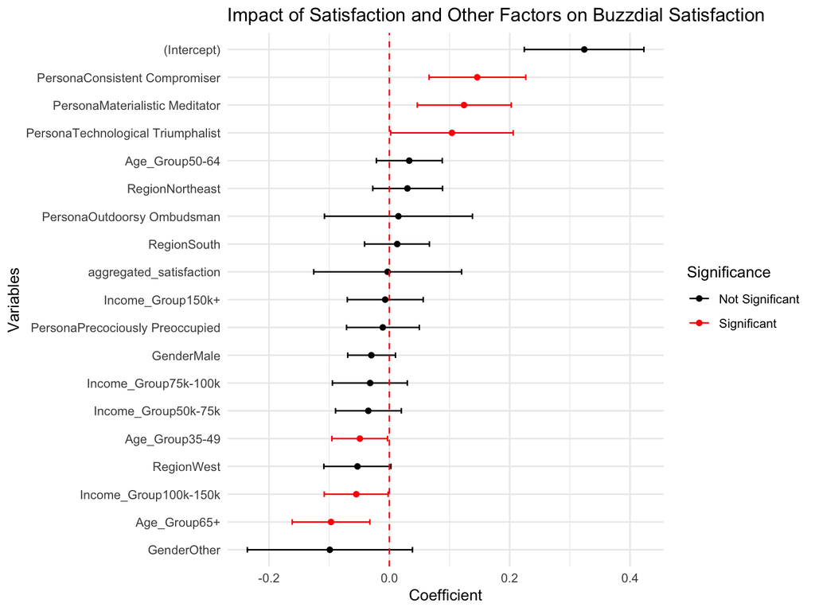

**Results**:

Aggregated Satisfaction itself has a negative coefficient (**-0.003**), but it is not significant (**p-value = 0.963**), indicating that overall trends in satisfaction with other products have no measurable impact on satisfaction with Buzzdial phones.

**Interpretation**:

Other Variables: